# 心理ネットワークアプローチ

## anhedoniaに介入

介入で、ある程度の症状低減(青)

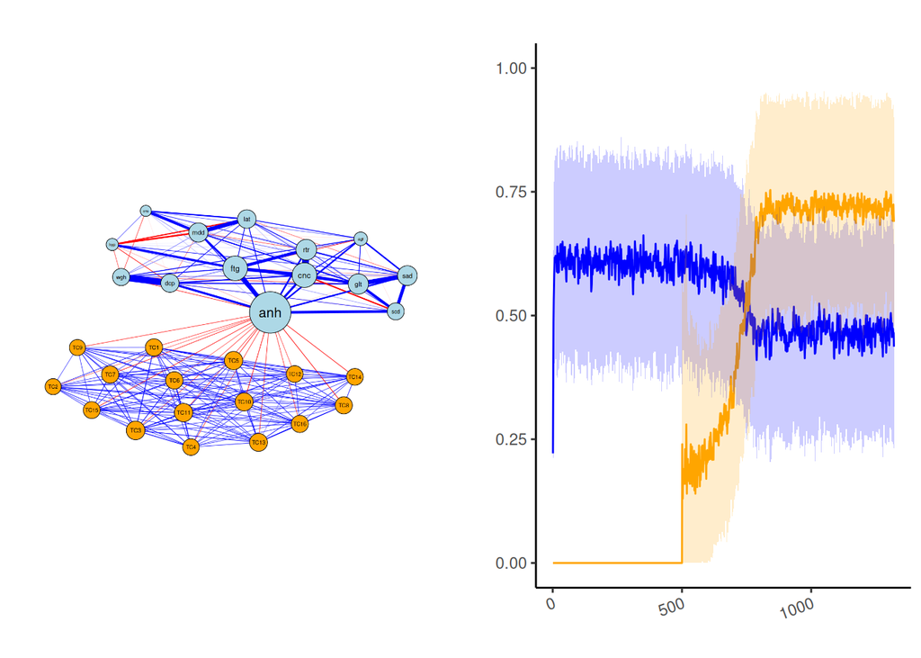

## anhedonia,concen,fatigueに介入

- anhedonia,concen,fatigueに負の影響を与える（低減させる）ノードを追加していくシミュレーションを実施

```r
net_sim_02 <- simulate_treatment_network(
  W_init = weights, #重み
  b_init = thresholds, #閾値
  target = c(0,0,0,0,0,0,0,1,0,0,1,1,0,0), #３変数を１に
  connectivity = 1.0, #全体的な接続の強さ
  edge_between_TC = 1, #TCノード間の接続の強さ
  weight_bias = 1, #症状とTCノードの重みの強さ
  TB = 1, #閾値の値の高さ
  trial = 100, #繰り返し回数(複数回行って平均を取っている)
  baseline_iteration = 500, #ベースラインのステップ数
  num_TC = 16, #TCノードの数
  TC_iteration_per_component = 20, #何ステップごとにTCを追加するか
  follow_up_iteration = 500, #TCを全て追加した後のフォローアップ期間
  symptom_name = node_names_bi
 )
```

## anhedonia,concen,fatigueに介入

anhedonia単体よりも症状低減(青)

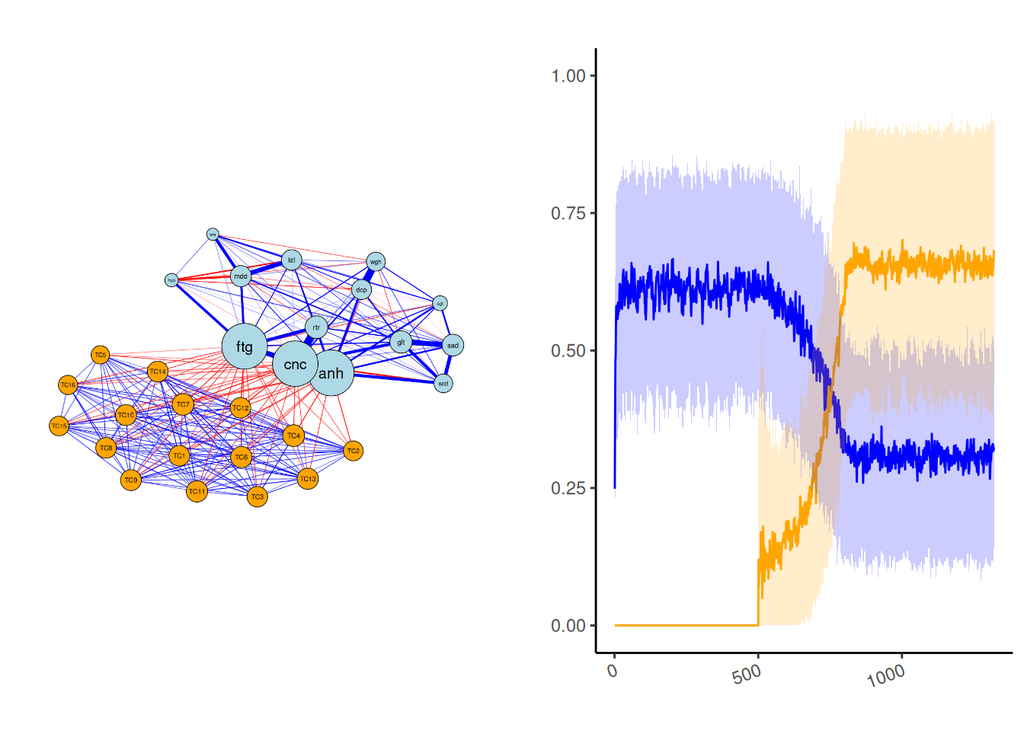

## 症状ネットワークへの介入

- 中心性の高い症状をターゲットにすることで、他の症状にも波及効果が生じる
- 今回のシミュレーションでも示されているが、１つの症状だけをターゲットとするよりも、複数の症状の方が効果的であることが多い
- 今回は示されてないが、症状ネットワーク内にクラスターがある場合は、中心性だけでなく、それぞれのクラスターに介入することが効果的なこともある

## ワーク

1. 関心のあるテーマに近いオープンデータもしくはご自身のデータを使って、心理ネットワーク分析を実施してみよう！
2. ネットワークシミュレーションで、他の症状ノードへの介入効果を調べてみよう！

# 縦断データのネットワーク分析

## 縦断データ

- 縦断データは、複数人を対象に、繰り返し測定を行ったデータ
- 個人間の違いと個人内変動を同時に扱うことができる
- 測定間隔がある程度広く頻度が低い場合はパネルデータ、測定間隔が狭く頻度も多い場合は経験サンプリングデータ

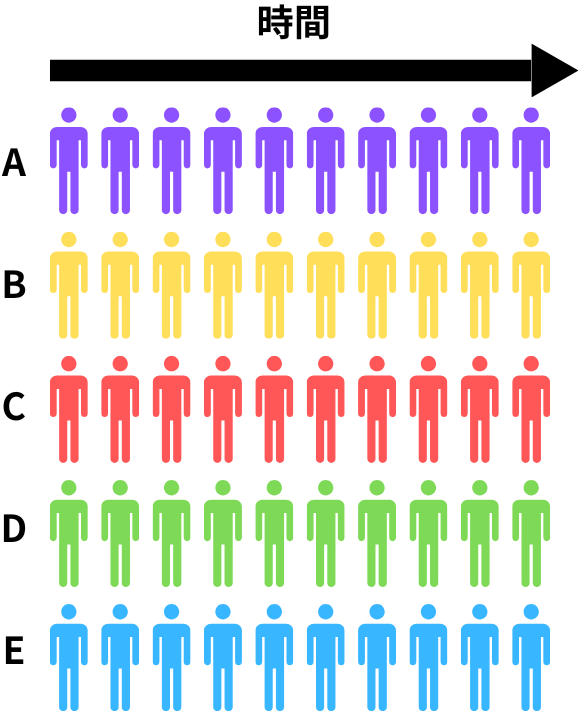

## 横断的分析

- 横断的分析は特定の時点での個人間での変数間の関連を扱う
- 時間的に変化する変数を扱う場合、参加者は他の時点では異なる反応を示したかも（個人内効果と個人間効果の混同）
- 個人間での変数間の関係は、個人内で生じるとは限らない

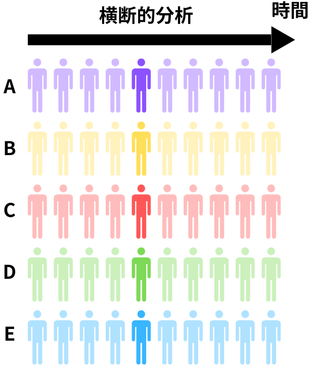

## 個人内分析

- 特定の参加者の時系列データを対象に、個人内での変数間の関係を扱う
- 特定の人における個人内関連性が明らかになるため、シングルケースの理解・介入に使える
- あくまで１事例の結果であり、他の人に一般化できるとは限らない

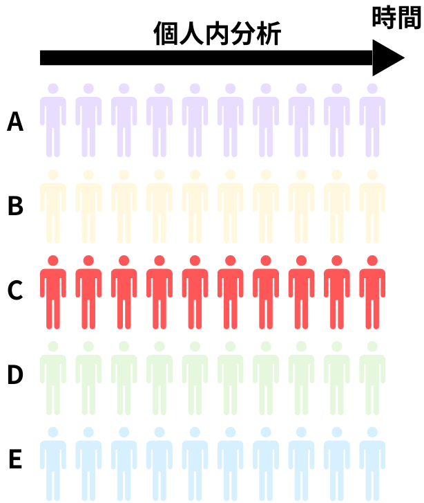

## 固定効果分析

- 複数人に繰り返し測定を行って、人の次元でならした平均的な人における個人内での変数間の関連性を扱う。集団としての個人内関連性を議論したい場合に使う
- 集団のネットワークの下に個人のネットワークがおかれるようなマルチレベルモデルを使う（本WSでは扱わない） (Bringmann et al. 2013)

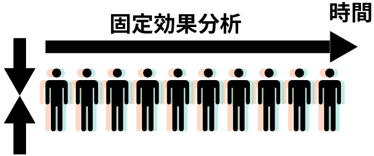

## 個人間分析

- 時間的に安定した変数間の関連を扱う（≠横断的分析）
- 繰り返し測定をした上で、時間の次元でならした安定的な平均を使って、個人間の関連性を分析する
- 集団のネットワークの下に個人のネットワークがおかれるようなマルチレベルモデルを使う（本WSでは扱わない） (Bringmann et al. 2013)

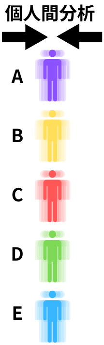

## 個人間と個人内の違い

- 「タイピングのスピード」と「スペルミス」との関係の例(Epskamp, Hoekstra, et al. 2022)
- 「ある人が自分の平均よりも速いスピードでタイピングしないといけなくなると、スペルミスが増える（正の関連）」（個人内効果）
- 「タイピングのスピードが速い人ほど（タイピングに慣れているほど）、スペルミスが少ない（負の関連）」（個人間効果）
- 個人内効果と個人間効果は逆の関係になることもあるため、混同しないようにする必要がある

## タイムフレームを意識

- 縦断データの分析では、測定の時間間隔を意識する
- 測定範囲内で変化しない変数を測定しても、変数間の関連性は捉えられない（１週間の経験サンプリングで、「虐待の有無」と「うつ病発症」との関係を見ても意味がない）
- 縦断データ分析では、変数が測定範囲内で変化することを確認したり、変化が期待できるような変数や時間間隔を選ぶ

## 経験的効果と同時性効果

- 縦断データのネットワーク分析では、経時間的効果（temporal effects）と同時性効果（contemporaneous effects）を区別できる
- 経時的効果：ある時点の変数が次の時点の変数に与える影響
- 同時性効果：経時的効果を統制した上での同一時点の変数間の関連性

## 運動と元気

- 「運動」と「元気」の関係の例(Epskamp, Waldorp, et al. 2018)
- 運動した次の時点(1~2時間後)は元気が低下（疲れる）＜経時的効果＞
- 運動している時は、元気＜同時性効果＞

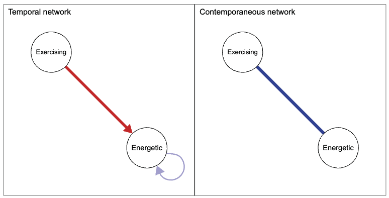

## 経時的/同時性/個人間ネットワーク

- 経時的ネットワーク(temporal networks): 時点をまたいだ個人内関連からなるネットワーク
- 同時性ネットワーク(contemporaneous networks): 同一時点における個人内関連からなるネットワーク
- 個人間ネットワーク(between-person networks): 安定的な平均値同士の関連を複数の参加者の間で検討したネットワーク（複数参加者に対して、マルチレベル推定によって推定できる）
- 以降では、臨床応用を念頭に、単一事例に対する経時的/同時性ネットワークを扱う

## GVARモデル

- グラフィカルVAR(graphical vector auto-regression)モデルは、個人の時系列データから経時的/同時性ネットワークを同時に推定する方法(Epskamp, Waldorp, et al. 2018)
- ラグ１のVARモデルは、時点tの変数ベクトルが、時点t-1の変数ベクトルによって予測される。GVARモデルは、VARモデルとGGMを組み合わせたもの
- GVARモデルの詳細は、大水拓海 and 国里愛彦 (2025) 参照

## GVARモデル：$\boldsymbol{B}$

- GVARでは、参加者の時点tの反応ベクトル$\boldsymbol{y}_{t}$は、１つ前の時点t-1の反応ベクトル$\boldsymbol{y}_{t-1}$から予測される($\boldsymbol{\epsilon_{t}}$ は誤差項)。反応ベクトル$\boldsymbol{y}_{t}$は測定した変数の数ある

$\boldsymbol{y}_{t} = \boldsymbol{B} \boldsymbol{y}_{t-1} + \boldsymbol{\epsilon_{t}}$

- $\boldsymbol{B}$は変数の数×変数の数の行列になり、１つ前の変数から次の時点の変数への影響を表す。$\boldsymbol{B}$から経時的ネットワークを計算する

## GVARモデル：$\boldsymbol{K}$

- $\boldsymbol{y}_{t} = \boldsymbol{B} \boldsymbol{y}_{t-1} + \boldsymbol{\epsilon_{t}}$の誤差項$\boldsymbol{\epsilon_{t}}$は、以下のように平均0、分散共分散行列$\boldsymbol{K}^{-1}$の正規分布に従う

$\boldsymbol{\epsilon_{t}} \sim N(0, \boldsymbol{K}^{-1})$

- $\boldsymbol{K}$は精度行列であり、その逆数は分散共分散行列になる。精度行列は、特定の変数間の関連について他の変数を統制したものであり、これから偏相関行列を計算できる。$\boldsymbol{K}$から同時性ネットワークを計算する

## 標準化: PDC と PCC

- PDC (Partial Directed Correlations) :$\boldsymbol{B}$を標準化したもの(図左)
- PCC (Partial Contemporaneous Correlations): $\boldsymbol{K}$を標準化したもの（図右）

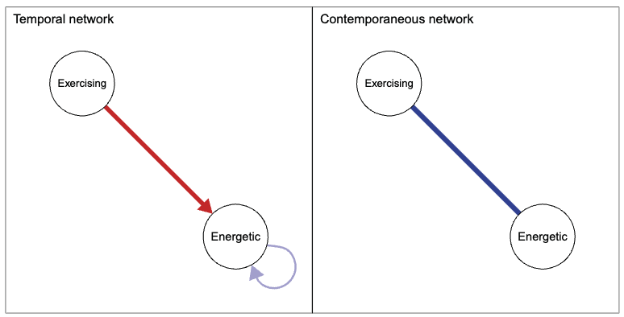

## パラメータ推定：正則化

- 全てのエッジがあるネットワーク（飽和モデル）は解釈しにくい
- 不要なエッジを除いたエッジの推定のために、LASSOアルゴリズムが用いられる。$\lambda$はチューニングパラメータであり、大きくするほど正則化が強くなり、ネットワークはスパースになる。graphicalVARパッケージでは、情報量規準を用いて最適な$\lambda$を選択する

$L(\mathbf{B}, \mathbf{K}) = - \log | \mathbf{K} | + \mathrm{tr}(S\mathbf{K}) + \lambda_{\beta} \| \mathbf{B} \|_{1} + \lambda_{\kappa} \| \mathbf{K} \|_{1}$

## モデル評価

- モデル評価について、graphicalVARパッケージでは、ベイズ情報量規準(BIC)と拡張ベイズ情報量規準(EBIC)を用いる（qはパラメータ数、Nはサンプルサイズ、nは変数数、Lは対数尤度）

$\mathrm{BIC} = q \cdot \ln(N) - 2L$

$\mathrm{EBIC} = q \cdot \ln(N) + 4\gamma \ln(n) - 2L$

- EBICは、BICに$4\gamma \ln(n)$が追加されており、変数数が多いほど高くなるため、よりスパースなモデルを選択する傾向がある(EBICは$\gamma$を0にするとBICになる)

## サンプルサイズ、欠測への対応

- サンプルサイズ（時点数）が多いほど、正確に推定できるが、参加者の負担などを考えると増やすのが難しいことも多い
- 測定時点が100程度の場合のシミュレーション研究からは、ノード数は10個以下(可能なら6個程度）が望ましい(Mansueto et al. 2022)
- 時系列データは欠測が生じることが多い。欠測がランダムなものである場合は、カルマンフィルター代入法、完全情報最尤推定法も使える

## データの定常性

- VARモデルの前提条件としてデータの定常性（stationarity）がある。もしトレンド（上昇・下降、周期性）が存在する場合、それらを除去（detrend）する必要がある
- トレンドの除去方法としては、線形トレンドの回帰残差を用いる方法などがある
- また、トレンドを除去するのではなく、積極的に時間的変化をモデル化する方法もある。 詳しくは、[「ネットワークにおける変化のモデリング」](https://ykunisato.github.io/ccp-lab-slide/tws-psynet-2023/slide.html#/title-slide)を参照

## Rパッケージの読み込み

- graphicalVARパッケージを使用して、縦断データから経時的および同時性ネットワークを推定

```r
library(tidyverse)
library(qgraph)
library(graphicalVAR)
```

## 用いるデータの入手方法

- Epskamp, Borkulo, et al. (2018) のデータを用いるため、[論文のページ](https://journals.sagepub.com/doi/10.1177/2167702617744325#fn1-2167702617744325)の一番下にあるSupplementary Materialのepskampsupplementary2_data.csvをダウンロードする

[figure not shown]

## 用いるデータ

- 1名のうつ病患者（女性、53歳, ECTによる部分寛解）から経験サンプリングでデータ収集している
- リラックス(relaxed)、悲しい(sad)、緊張(nervous)、集中(concentration)、疲労(tired)、反すう(rumination)、身体的不快感(bodily discomfort)の７つについて、1（全くない）から7（非常に）までの7件法で評価
- 2週間、1日5回、3時間ごとに、所要時間3～5分で実施された。最大回答回数は70回だが、実際は欠測がある

## データの読み込み

- RStudioにepskampsupplementary2_data.csvを配置して(今回は用意してあります)、以下のコードでデータを読み込む＆時間関係の変数の処理をする

```r
# データの読み込み
data_single <- read_csv("epskampsupplementary2_data.csv") %>%
  rename('bodily_discomfort' = 'bodily\ndiscomfort')
# 症状変数の名前
symptom_names <- c("relaxed","sad","nervous","concentration","tired","rumination","bodily_discomfort")
# 時間の情報
data_single$time <- as.POSIXct(data_single$time)
# 日付の情報
data_single$date <- as.numeric(as.Date(data_single$time))
```

## beep変数の作成

- GVARモデルでは、定間隔で測定されていることが前提となる
- 欠測がある場合に、それが分かるように、１日の内の何番目の測定かを示すbeep変数を作成する

```r
beep <- NULL
for (i in 1:length(data_single$date)) {
  if(i == 1){
    beep[1] <- 1
  } else if(data_single$date[i] == data_single$date[i - 1]){
    beep[i] <- beep[i - 1] + 1
  } else {
    beep[i] <- 1
  }
}
data_single$beep <- beep
```

## 線形トレンドの可視化

- GVARモデルでは、データの定常性が前提となるため、線形トレンドがないか確認する必要がある
- 各変数について時間的な変化をプロットして確認する

```r
# データを縦長形式(long format)に変換
data_long <- data_single %>%
  pivot_longer(
    cols = all_of(symptom_names),
    names_to = "symptom",
    values_to = "value"
  )

# トレンドを視覚的に確認
ggplot(data_long, aes(x = time, y = value)) +
  geom_line(alpha = 0.6) +
  facet_wrap(~ symptom, scales = "free_y") +
  theme_minimal(base_size = 12)
```

## 線形トレンドの可視化

tiredに上昇、ruminationに下降トレンド？

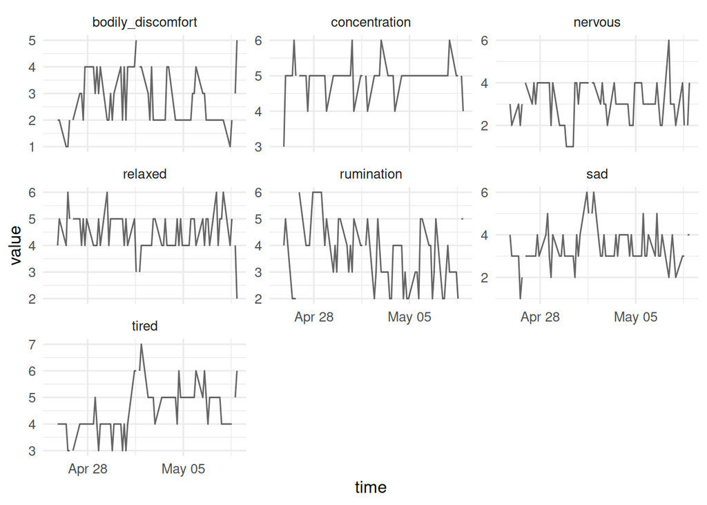

## デトレンド（時間トレンドの除去）

- 線形回帰を使って時間が有意な“tired”と”rumination”のトレンドを除去

```r
for (v in seq_along(symptom_names)){
  ff <- as.formula(paste0(symptom_names[[v]]," ~ time"))
  fit <- lm(ff, data = data_single)
  if (anova(fit)$P[1] < 0.05){
    message(paste("Detrending variable",symptom_names[[v]]))
    data_single[[symptom_names[v]]][!is.na(data_single[[symptom_names[[v]]]])] <- residuals(fit)
  }
}
```

```
Detrending variable tired
Detrending variable rumination
```

## トレンドの除去の効果の確認

- トレンドの除去の効果をプロットして確認する

```r
# データを縦長形式(long format)に変換
data_long <- data_single %>%
  pivot_longer(
    cols = all_of(symptom_names),
    names_to = "symptom",
    values_to = "value"
  )

# トレンドを視覚的に確認
ggplot(data_long, aes(x = time, y = value)) +
  geom_line(alpha = 0.6) +
  facet_wrap(~ symptom, scales = "free_y") +
  theme_minimal(base_size = 12)
```

## 線形トレンドの除去の効果の確認

tiredとruminationのトレンドが除去されている

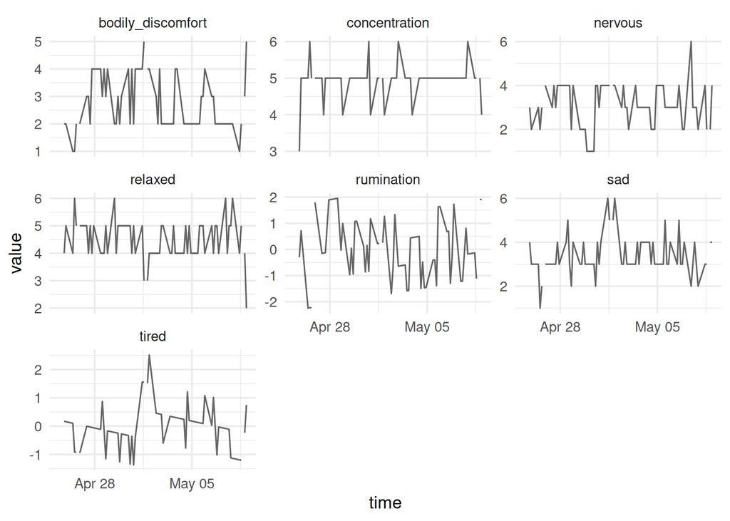

## ネットワーク推定(EBIC)

- graphicalVAR()のデフォルトの$\gamma$は0.5のためEBICを用いた推定になる
- データに欠測がある場合デフォルトではリストワイズ削除。負の相関は破線にすると見やすい（negDashed = TRUE）

```r
gvar_result1 <- graphicalVAR(data_single,
                        vars = symptom_names,
                        dayvar = "date",
                        beepvar = "beep")

layout(t(1:2))
plot(gvar_result1, "PDC", layout = "circle",fade = FALSE, negDashed = TRUE)
plot(gvar_result1, "PCC", layout = "circle",fade = FALSE, negDashed = TRUE)
```

## ネットワーク推定(EBIC)

経時的ネットワークにエッジはない。同時性ネットワークでエッジを確認

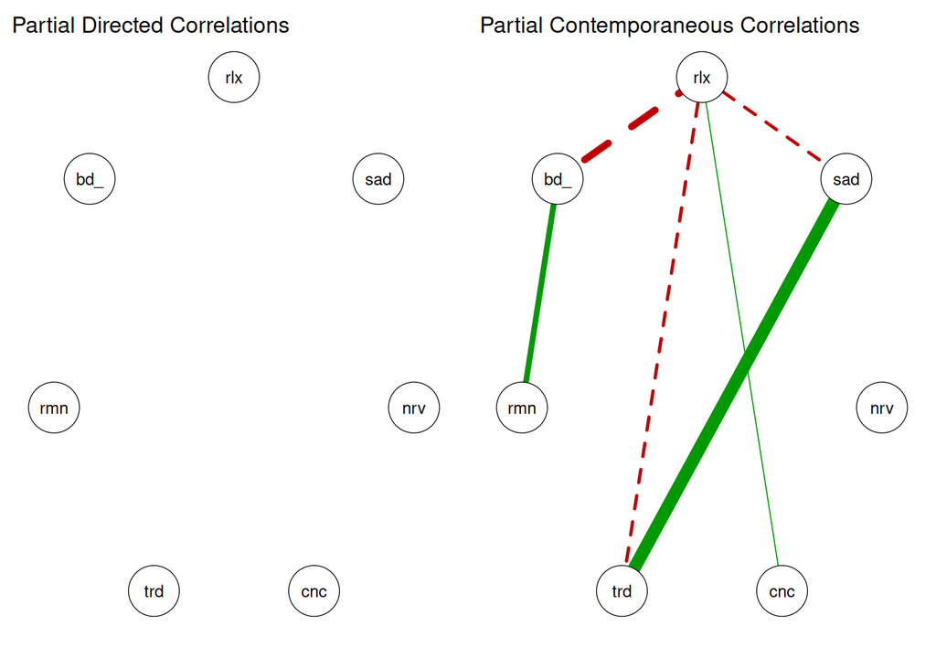

## ネットワーク推定(BIC)

- $\gamma$を0にした場合はBICでの推定になる

```r
gvar_result2 <- graphicalVAR(data_single,
                        vars = symptom_names,
                        gamma = 0,
                        dayvar = "date",
                        beepvar = "beep")

layout(t(1:2))
plot(gvar_result2, "PDC", layout = "circle",fade = FALSE, negDashed = TRUE)
plot(gvar_result2, "PCC", layout = "circle",fade = FALSE, negDashed = TRUE)
```

## ネットワーク推定(BIC)

BICの方がエッジが検出されやすくなり、経時的ネットワークでエッジを確認

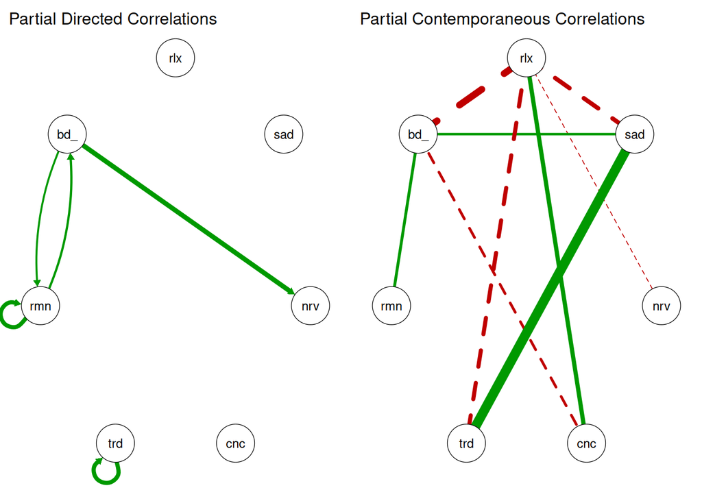

## $\lambda$（正則化の強さ）の調整

- $\lambda$を大きくすると正則化が強くなるので、$\lambda$の最小値を0.9に設定して推定

```r
gvar_result3 <- graphicalVAR(data_single,
                        vars = symptom_names,
                        gamma = 0,
                        lambda_min_kappa = 0.9,
                        lambda_min_beta = 0.9,
                        dayvar = "date",
                        beepvar = "beep")

layout(t(1:2))
plot(gvar_result3, "PDC", layout = "circle",fade = FALSE, negDashed = TRUE)
plot(gvar_result3, "PCC", layout = "circle",fade = FALSE, negDashed = TRUE)
```

## ネットワーク推定(BIC)

$\lambda$を大きくしたので、エッジが減少

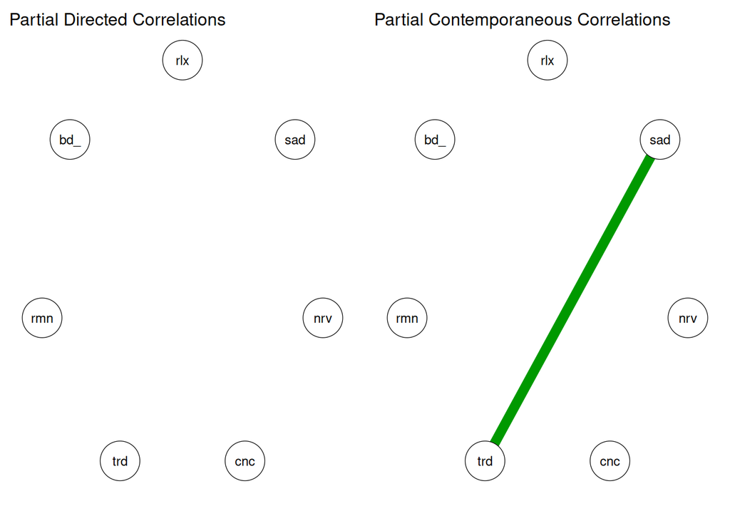

## 事例定式化とGVARモデル

- PBTに限らず、CBTの事例定式化（ケースフォーミュレーション）に個人から収集したデータのネットワーク分析は有用だろう
- 経時的ネットワークと同時性ネットワークを組み合わせて、クライエントの変数間の悪循環を理解できる可能性がある
- 対話によるケースフォーミュレーションをデータによって支持できる可能性もあるし、予想外な視点を提供する可能性もある

# 微分方程式によるシミュレーション

## 微分方程式モデル

- GVARモデルはデータ分析に有用だが、症状の動的な変化を理解するために、微分方程式モデルを用いたシミュレーションも有用
- 精神障害の症状の時間的変化は非常に短時間で生じるものもあり（パニック発作など）、微分方程式モデルが有用かもしれない
- Robinaugh et al. (2024) は、パニック症の微分方程式モデルを作ってシミュレーションを実施しているので、簡単に紹介する

## パニック症の微分方程式モデル

- Robinaugh et al. (2024) は、パニック症の認知行動モデルを微分方程式モデルで定式化
- 例えば、覚醒度の変化は、$\frac{dA}{dt} = \alpha_A (\beta_A T - A)$ と表現（Tは知覚された脅威）
- モデルの詳細は省略し、モデルの挙動を紹介

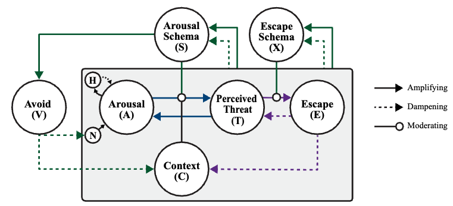

## PanicModelパッケージ

- Robinaugh et al. (2024) が論文内で行ったシミュレーションのコードは、[PanicModelパッケージ](https://github.com/jmbh/PanicModel)として配布されている
- 以降では、PanicModelパッケージを用いてシミュレーションを行うので、読み込む
- 最初に、乱数のシードを固定

```r
library(PanicModel)
set.seed(1234)
```

## 摂動を入れたシミュレーション

- システムはランダムに揺らぐので、少し刺激を入れた場合のシミュレーションをする

```r
# シミュレーションの設定
perturb_time <- 10
perturb_strength <- 0.60
parameters_specified <- list("Tx" = list("minuteP" = perturb_time, "strengthP" = perturb_strength))
initial_specified <- list("S" = 0.60)
# シミュレーションの実行
results <- simPanic(time = 0:60,
                  initial = initial_specified,
                  parameters = parameters_specified,
                  pbar = FALSE)
results_plot <- results$outmat
# プロット
plot.new()
plot.window(xlim = c(0, length(results_plot$A)),  ylim = c(-.75, 1))
axis(1); axis(2, las = 2)
mtext("Minutes", side = 1, line = 3,cex = 1.25)
rect(perturb_time, -0.5, (perturb_time+1), perturb_strength, col = "grey90", border = FALSE)
text(perturb_time, -0.6, "Perturbation")
lines(results_plot$E, col = "red", lwd = 3)
lines(results_plot$H, col = "red", lty = "dashed", lwd = 3)
lines(results_plot$A, col = "grey", lwd = 3)
lines(results_plot$PT, col = "black", lwd = 3)
legend("topright", legend = c("Arousal", "Perceived Threat", "Escape", "Homeostatic Feedback"),
       col = c("grey", "black", "red", "red"),
       lty = c(1,1,1,2), bty = "n")
```

## 摂動を入れたシミュレーション

摂動(急な覚醒度の上昇)を入れると、覚醒、知覚された脅威が上がり、遅れて逃避行動、そして、ホメオスタシスフィードバックが上がる

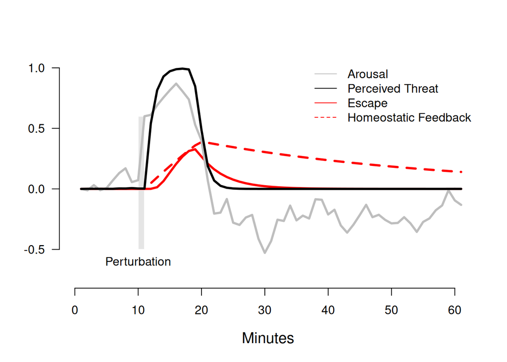

## 摂動を入れたシミュレーション

- 摂動を入れたシミュレーションは、確率的な変動のために、シミュレーションを行うごとに変化する。10回シミュレーションを動かして確認する

```r
# シミュレーションの設定
perturb_time <- 10
perturb_strength <- 0.60
parameters_specified <- list("Tx" = list("minuteP" = perturb_time, "strengthP" = perturb_strength))
initial_specified <- list("S" = 0.60)
N_sim <- 10
# シミュレーションの実行
results <- list()
for(i in 1:N_sim) {
  out <- simPanic(time = 0:50,
                  parameters = parameters_specified,
                  initial = initial_specified,
                  pbar = FALSE)

  results[[i]] <- out
}
# プロット
plot.new()
plot.window(xlim = c(0, length(results[[1]]$outmat$AF)),  ylim=c(-.75, 1))
axis(1); axis(2,las=2)
mtext("Minutes", side = 1, line = 3,cex = 1.25)
rect(perturb_time, -.5, (perturb_time+1), perturb_strength, col = "grey90", border = FALSE)
text(perturb_time,-0.6,"Perturbation")
for(i in 1:length(results)){lines(results[[i]]$outmat$AF, col = "black", lwd = .5)}
legend("topright", legend = c("Fear"),
       col = c("black"),
       lty = c(1), bty="n")
```

## 摂動を入れたシミュレーション

摂動を入れたシミュレーション(10名分) 確率的な変動によって恐怖反応が異なる

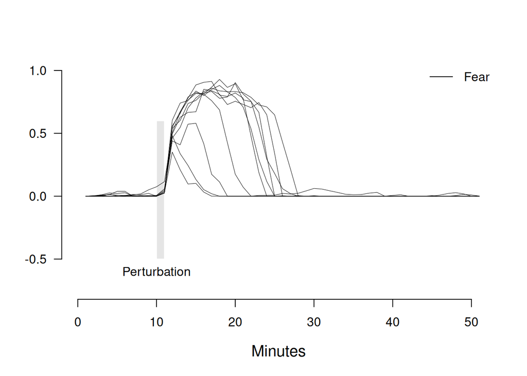

## CBTのシミュレーション

- Robinaugh et al. (2024) は、覚醒スキーマの効果をシミュレーションし、覚醒スキーマが強いと摂動に対して脆弱であることを示した
- パニック症のモデルへの心理的介入の作用メカニズムをモデル化した上で、認知行動療法(CBT)の作用プロセスをシミュレーション

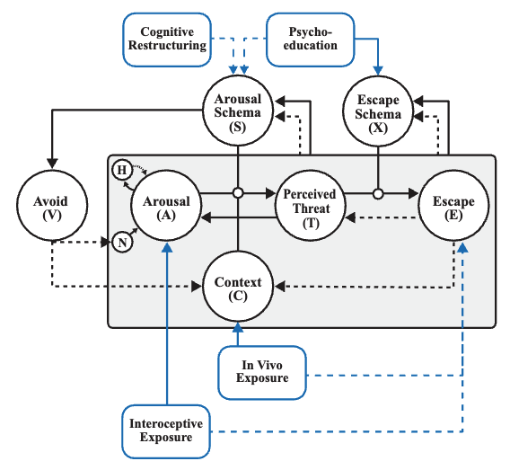

## CBTのシミュレーション

```r
# シミュレーションの設定
baseline_weeks <- 0
baseline_days <- 1
tx <- list("I1" = baseline_days+baseline_weeks*7+c(1),
           "I2" = baseline_days+baseline_weeks*7+c(1),
           "I3" = (baseline_days+baseline_weeks+(1:2)*7)+c(1),
           "I4" = (baseline_days+baseline_weeks*7)+7+(1:(7*4)),
           "I5" = baseline_days+(baseline_weeks+3)*7+(1:14)[rep(c(TRUE,TRUE), 7)])
parameters_specified <- list("Tx" = list("I123_alpha" = rbeta(n = 1, 1, 9),
                                         "I4Adh" = rbeta(n = 1, 2, 2/3),
                                         "I4RdEs" = rbeta(n = 1, 2, 2/3)))
time <- 0:(60*24*7*5)
initial_specified <- list("S" = 0.80, "X" = 0.20)
# シミュレーションの実行
out4 <- simPanic(time = time,
                  parameters = parameters_specified,
                  initial = initial_specified,
                  tx = tx,
                  pbar = FALSE)
# プロットの準備
results4 <- out4$outmat
endbase <- (60*24*7) * baseline_weeks
endtreat <- endbase + (60*24*7)*5
exposures_x <- out4$adherence*(endbase+(7*60*24) + seq(1:length(out4$adherence))*60*24)
exposures_x[exposures_x==0] <- NA
exposures_y <- rep(0, length(exposures_x))
cog_x <- c(endbase + (7*60*24), endbase + (14*60*24))
cog_y<-rep(-.025, length(cog_x))
psyed_x <- c(endbase + (0*60*24), endbase + (0*60*24))
psyed_y <- rep(-.025, length(psyed_x))
cols <- vector()
cols[1] <- rgb(1.0, 0, 0, alpha = .05)
cols[2] <- rgb(0, 0, 1.0, alpha = .05)
# プロット
{plot.new()
par(mar = c(5, 4, 4, 10),xpd = TRUE)
plot.window(xlim = c(0, length(results4$A)),  ylim = c(0, 1))
axis(1, at = seq(endbase, length(results4$A), by = (60*24*7)), labels = c("S1", "S2", "S3", "S4","S5", "E"))
axis(2, at = seq(0, 1, .25), las = 2)
mtext("Weeks", side = 1, line = 4, cex = 1.25)
polygon(c(seq(1, length(results4$S)), rev(seq(1,length(results4$S)))), c(results4$S, rep(0,length(results4$S))), col = cols[1], border = NA)
polygon(c(seq(1, length(results4$X)), rev(seq(1,length(results4$X)))), c(results4$X, rep(0,length(results4$X))), col = cols[2], border = NA)
lines(results4$PT, col = "dark grey")
lines(results4$S, col = "red", lwd = 3)
lines(results4$X, col = "blue", lwd = 3)
points(exposures_x, exposures_y, pch = 19, col = "black")
points(cog_x, cog_y, pch = 15, col = "black")
points(psyed_x, psyed_y, pch = 17, col = "black")
legend("topright", 1, legend = c("Arousal Schema","Escape Schema"),
       inset = c(- 0.4, 0),
       col = c("red", "blue"),
       lty = 1, bty = "n")
legend("right", 1, legend = c("Psychoeducation", "Cognitive Restructuring", "Exposure Exercise"),
       inset = c(- 0.45, 0),
       pch = c(17, 15, 19), bty = "n")}
```

## CBTのシミュレーション

心理教育、認知再構成、エクスポージャーにより、覚醒スキーマが下がり、逃避スキーマが上がることで、恐怖が減少

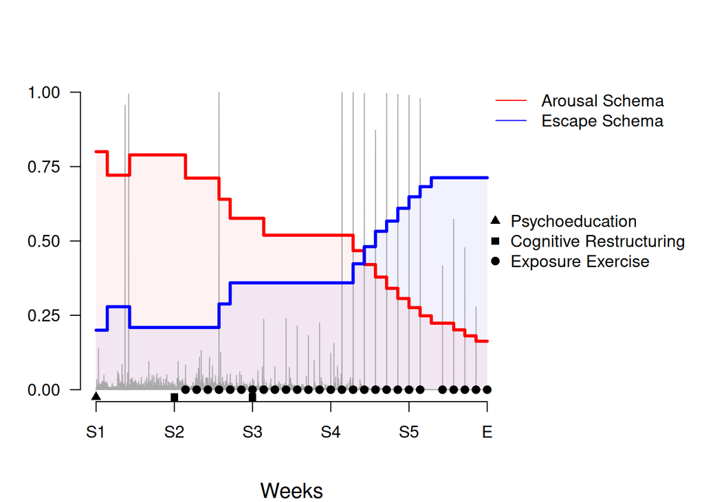

## シミュレーションについて

- シミュレーションは、あくまで特定の仮定の上で設定されたモデルの挙動を見ているだけであり、それによって何かを実証するものではない
- しかし、モデルの挙動を理解したり、モデルに基づく予測を立てたり、治療介入の作用メカニズムを検討したりする上で有用
- ネットワークシミュレーションも微分方程式を用いたシミュレーションも始まったばかりだが、今後の発展が期待される

## ワーク

- 関心のある時系列データを用いて、GVARモデルによるネットワーク分析を実施してみよう！
- [「openESM」](https://openesmdata.org/)は経験サンプリングを用いたオープンデータを読み込めるRパッケージ（2025年10月22日に Siepe et al. (2025) がプレプリントを発表）
- 現段階では、残念ながら、Rパッケージのエラーが生じているが、[「openESM」](https://openesmdata.org/)のサイトから、データをダウンロードして使うことができる

## 謝辞

- 本ワークショップの資料は、研究室の藁科佳奈さん、[大水拓海さん](https://psytakumio.github.io/takumiomizu/index.html)、加藤めぐみさんとの共同研究がもとになっています。日頃からの刺激的な議論に感謝申し上げます
- 科研費の基盤Bプロジェクト「心理ネットワークアプローチの臨床応用に向けた基盤構築とケース研究」を通して、心理ネットワークの理解と応用に関して議論する場を提供してくださる樫原潤さんにも感謝申し上げます

## 引用文献

Blanken, T. F., Adela-Maria. Isvoranu, and Sacha. Epskamp. 2022. “Estimating Network Structures Using Model Selection.” In *Network Psychometrics with r: A Guide for Behavioral and Social Scientists*, edited by Adela-Maria. Isvoranu, Sacha. Epskamp, L. J. Waldorp, and D. Borsboom, 111--132. London: Routledge.

Borsboom, D, A O J Cramer, E I Fried, A M Isvoranu, D J Robinaugh, J Dalege, and H L J van der Maas. 2022. “Network Perspectives.” In *Network Psychometrics with r: A Guide for Behavioral and Social Scientists*, edited by Adela-Maria. Isvoranu, Sacha. Epskamp, L. J. Waldorp, and D. Borsboom, 9–27. London: Routledge.

Boschloo, Lynn, Claudia D van Borkulo, Mijke Rhemtulla, Katherine M Keyes, Denny Borsboom, and Robert A Schoevers. 2015. “The Network Structure of Symptoms of the Diagnostic and Statistical Manual of Mental Disorders.” *PloS One* 10 (9): e0137621.

Bringmann, Laura F, Nathalie Vissers, Marieke Wichers, Nicole Geschwind, Peter Kuppens, Frenk Peeters, Denny Borsboom, and Francis Tuerlinckx. 2013. “A Network Approach to Psychopathology: New Insights into Clinical Longitudinal Data.” *PloS One* 8 (4): e60188.

Cramer, Angélique O J, Claudia D van Borkulo, Erik J Giltay, Han L J van der Maas, Kenneth S Kendler, Marten Scheffer, and Denny Borsboom. 2016. “Major Depression as a Complex Dynamic System.” *PloS One* 11 (12): e0167490.

Epskamp, Sacha, Claudia D van Borkulo, Date C van der Veen, Michelle N Servaas, Adela-Maria Isvoranu, Harriëtte Riese, and Angélique O J Cramer. 2018. “Personalized Network Modeling in Psychopathology: The Importance of Contemporaneous and Temporal Connections.” *Clinical Psychological Science* 6 (3): 416–27.

Epskamp, Sacha, Denny Borsboom, and Eiko I Fried. 2018. “Estimating Psychological Networks and Their Accuracy: A Tutorial Paper.” *Behavior Research Methods* 50 (1): 195–212.

Epskamp, Sacha, Jonas M B Haslbeck, Adela-Maria. Isvoranu, and Claudia D van Borkulo. 2022. “Pairwise Markov Random Fields.” In *Network Psychometrics with r: A Guide for Behavioral and Social Scientists*, edited by Adela-Maria. Isvoranu, Sacha. Epskamp, L. J. Waldorp, and D. Borsboom, 93–110. London: Routledge.

Epskamp, Sacha, R. H. A. Hoekstra, J Burger, and L. J. Waldorp. 2022. “Longitudinal Design Choices: Relating Data to Analysis.” In *Network Psychometrics with r: A Guide for Behavioral and Social Scientists*, edited by Adela-Maria. Isvoranu, Sacha. Epskamp, L. J. Waldorp, and D. Borsboom, 9–27. London: Routledge.

Epskamp, Sacha, Lourens J Waldorp, René Mõttus, and Denny Borsboom. 2018. “The Gaussian Graphical Model in Cross-Sectional and Time-Series Data.” *Multivariate Behavioral Research* 53 (4): 453–80.

Hofmann, Stefan, Steven C. Hayes, David N. Lorscheid, 菅原大地, 樫原潤, and 伊藤正哉(監訳). 2023. *プロセス・ベースド・セラピーをまなぶ : 「心の変化のプロセス」をターゲットとした統合的ビジョン*. 金剛出版.

Höller, Inken, Dajana Schreiber, Fionneke Bos, Thomas Forkmann, Tobias Teismann, and Jürgen Margraf. 2022. “The Mereology of Depression-Networks of Depressive Symptoms During the Course of Psychotherapy.” *International Journal of Environmental Research and Public Health* 19 (12).

Isvoranu, Adela-Maria, and Sacha Epskamp. 2021. “Which Estimation Method to Choose in Network Psychometrics? Deriving Guidelines for Applied Researchers.” *Psychological Methods*, November.

Isvoranu, Adela-Maria, Sacha Epskamp, Lourens Waldorp, and Denny Borsboom. 2022. *Network Psychometrics with r: A Guide for Behavioral and Social Scientists*. Taylor & Francis.

Mansueto, Alessandra C, Reinout W Wiers, Julia C M van Weert, Barbara C Schouten, and Sacha Epskamp. 2022. “Investigating the Feasibility of Idiographic Network Models.” *Psychological Methods*, January.

McNally, R J, P Mair, B L Mugno, and B C Riemann. 2017. “Co-Morbid Obsessive-Compulsive Disorder and Depression: A Bayesian Network Approach.” *Psychological Medicine* 47 (7): 1204–14.

Omizu, Takumi, and Yoshihiko Kunisato. 2024. “Exploring Effective Intervention Strategies for Depression as a Complex System: Targeted Interventions Through Network Simulations.” *The Japanese Psychological Research* 67 (2): 147–61.

Robinaugh, Donald J, Jonas M B Haslbeck, Lourens J Waldorp, Jolanda J Kossakowski, Eiko I Fried, Alexander J Millner, Richard J McNally, et al. 2024. “Advancing the Network Theory of Mental Disorders: A Computational Model of Panic Disorder.” *Psychological Review* 131 (6): 1482–1508.

Siepe, Björn S, Jonas M B Haslbeck, Matthias Kloft, Anabel Büchner, Yong Zhang, Eiko I Fried, and Daniel W Heck. 2025. “Introducing openESM: A Database of Openly Available Experience Sampling Datasets.” *PsyArXiv*, October.

国里愛彦, 藁科佳奈, 隅田昌孝, 村口ゆら, and 大水拓海. 2023. “横断データに対する心理ネットワーク分析のチュートリアル.” *専修人間科学論集心理学篇* 13 (1): 51–67.

大水拓海, and 国里愛彦. 2025. “単一事例研究への心理ネットワーク分析の適用 : graphicalVARを用いたチュートリアル.” *専修人間科学論集心理学篇* 15 (1): 45–56.